# Anonymous function ( Lambda Function )

What is an Anonymous Function (Lambda Function)?

Imagine you're trying to quickly calculate a tiny little thing, just once, right in the middle of another task. You wouldn't pull out your big recipe book, find a new blank page, write a full, named recipe, and then refer to it. Instead, you'd probably just scribble the quick calculation on a sticky note and use it immediately.

An anonymous function (or lambda function) in Python is like that sticky note:

- It's a small, unnamed function. It doesn't have a def and a function name.
- It's designed for quick, simple, one-off tasks, usually involving a single calculation or expression.
- You create it using the keyword lambda.

Why use them?

While you can always achieve the same result with a regular def function, lambda functions are used for:

- Conciseness: They allow you to write very short functions in a single line.
- Convenience: They're handy when you need a function for a very short period or as an argument to another function, and you don't want to formally def it.
- Common with Higher-Order Functions: They are frequently used with built-in functions like map(), filter(), and sorted(), which can take other functions as arguments.

Basic Structure (Syntax):

lambda arguments: expression

- lambda: The keyword that tells Python you're creating an anonymous function.
- arguments: The inputs the function takes (like x, y, or name). You can have zero or more.
- : The colon separates the arguments from the body of the function.
- expression: This is the single calculation or action the function performs. The result of this expression is what the lambda function "returns."

# Notebook structure

Comparative analysis of Lambda function implementation and utility function implementation of different scenarios

Example scenario

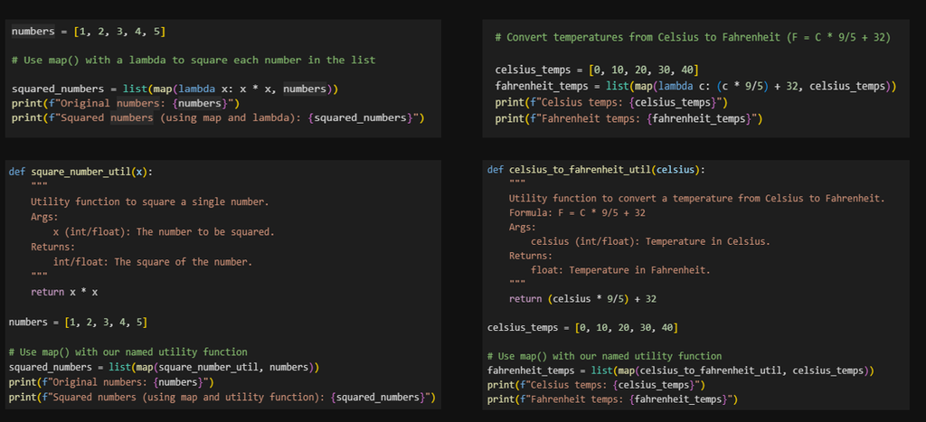

# 1. Simple Arithmetic / Transformation

We can use a lambda for quick calculations without formally defining a function.

### A. Writing 3 arithmetic function ( add , square , is_even ) using lambda function

```python
# A lambda function that adds two numbers

add_numbers = lambda x, y: x + y
print(f"Adding 5 and 3: {add_numbers(5, 3)}") # Output: 8

# A lambda function that squares a number
square = lambda num: num * num
print(f"Square of 7: {square(7)}") # Output: 49

# A lambda function to check if a number is even
is_even = lambda num: num % 2 == 0
print(f"Is 10 even? {is_even(10)}") # Output: True
print(f"Is 7 even? {is_even(7)}")   # Output: False
```

```
Adding 5 and 3: 8
Square of 7: 49
Is 10 even? True
Is 7 even? False
```

### B. How the utility function will look like for adding 2 numbers

Original Lambda:

- add_numbers = lambda x, y: x + y

```python
def add_numbers_util(x, y):
    """
    Utility function to add two numbers.
    Args:
        x (int/float): The first number.
        y (int/float): The second number.
    Returns:
        int/float: The sum of x and y.
    """
    return x + y

# Example usage:
print(f"Adding 5 and 3: {add_numbers_util(5, 3)}") # Output: 8
```

```
Adding 5 and 3: 8
```

### C. How the utility function will look like for squaring a number

Original Lambda:

- square = lambda num: num * num

```python
def square_util(num):

    """
    Utility function to square a given number.
    Args:
        num (int/float): The number to be squared.
    Returns:
        int/float: The square of the number.
    """
    return num * num

# Example usage:
print(f"Square of 7: {square_util(7)}") # Output: 49
```

```
Square of 7: 49
```

### D. How the Utility Function to Check if a Number is Even

Original Lambda:

- is_even = lambda num: num % 2 == 0

```python
def is_even_util(num):
    """
    Utility function to check if a number is even.
    Args:
        num (int): The integer to check.
    Returns:
        bool: True if the number is even, False otherwise.
    """
    return num % 2 == 0

# Example usage:
print(f"Is 10 even? {is_even_util(10)}") # Output: True
print(f"Is 7 even? {is_even_util(7)}")   # Output: False
```

```
Is 10 even? True
Is 7 even? False
```

# 2. Applying a Transformation to Each Item : map()

### A. Original Lambda Version : Squaring Each Number in a List & Converting Celsius to Fahrenheit

The map() function applies a given function to each item of an iterable (like a list) and returns an iterator of the results. Lambdas are perfect here.

```python
numbers = [1, 2, 3, 4, 5]

# Use map() with a lambda to square each number in the list

squared_numbers = list(map(lambda x: x * x, numbers))
print(f"Original numbers: {numbers}")
print(f"Squared numbers (using map and lambda): {squared_numbers}")


# Convert temperatures from Celsius to Fahrenheit (F = C * 9/5 + 32)

celsius_temps = [0, 10, 20, 30, 40]
fahrenheit_temps = list(map(lambda c: (c * 9/5) + 32, celsius_temps))
print(f"Celsius temps: {celsius_temps}")
print(f"Fahrenheit temps: {fahrenheit_temps}")
```

```
Original numbers: [1, 2, 3, 4, 5]
Squared numbers (using map and lambda): [1, 4, 9, 16, 25]
Celsius temps: [0, 10, 20, 30, 40]
Fahrenheit temps: [32.0, 50.0, 68.0, 86.0, 104.0]
```

### B. Utility Function Version : Squaring Each Number in a List

```python
def square_number_util(x):
    """
    Utility function to square a single number.
    Args:
        x (int/float): The number to be squared.
    Returns:
        int/float: The square of the number.
    """
    return x * x

numbers = [1, 2, 3, 4, 5]

# Use map() with our named utility function
squared_numbers = list(map(square_number_util, numbers))
print(f"Original numbers: {numbers}")
print(f"Squared numbers (using map and utility function): {squared_numbers}")
```

```
Original numbers: [1, 2, 3, 4, 5]
Squared numbers (using map and utility function): [1, 4, 9, 16, 25]
```

### C. Utility Function Version : Converting Celsius to Fahrenheit

```python
def celsius_to_fahrenheit_util(celsius):
    """
    Utility function to convert a temperature from Celsius to Fahrenheit.
    Formula: F = C * 9/5 + 32
    Args:
        celsius (int/float): Temperature in Celsius.
    Returns:
        float: Temperature in Fahrenheit.
    """
    return (celsius * 9/5) + 32

celsius_temps = [0, 10, 20, 30, 40]

# Use map() with our named utility function
fahrenheit_temps = list(map(celsius_to_fahrenheit_util, celsius_temps))
print(f"Celsius temps: {celsius_temps}")
print(f"Fahrenheit temps: {fahrenheit_temps}")
```

```
Celsius temps: [0, 10, 20, 30, 40]
Fahrenheit temps: [32.0, 50.0, 68.0, 86.0, 104.0]
```

# 3. Selecting Items Based on a Condition : filters()

The filter() function constructs an iterator from elements of an iterable for which a function returns True.

### A. Original Lambda Version : Filtering for Even Numbers & Filtering for Names Longer Than 4 Characters

```python
numbers = [1, 2, 3, 4, 5, 6, 7, 8, 9, 10]

# Use filter() with a lambda to get only even numbers

even_numbers = list(filter(lambda x: x % 2 == 0, numbers))
print(f"Original numbers: {numbers}")
print(f"Even numbers (using filter and lambda): {even_numbers}")


# Filter out short names from a list

names = ["Alice", "Bob", "Charlie", "David", "Eve"]
long_names = list(filter(lambda name: len(name) > 4, names))
print(f"Names: {names}")
print(f"Names longer than 4 chars: {long_names}")
```

```
Original numbers: [1, 2, 3, 4, 5, 6, 7, 8, 9, 10]
Even numbers (using filter and lambda): [2, 4, 6, 8, 10]
Names: ['Alice', 'Bob', 'Charlie', 'David', 'Eve']
Names longer than 4 chars: ['Alice', 'Charlie', 'David']
```

### B. Utility Function Version: Filtering for Even Numbers

```python
def is_number_even_util(number):
    """
    Utility function to check if a given number is even.
    Args:
        number (int): The number to check.
    Returns:
        bool: True if the number is even, False otherwise.
    """
    return number % 2 == 0

numbers = [1, 2, 3, 4, 5, 6, 7, 8, 9, 10]

# Use filter() with our named utility function
even_numbers = list(filter(is_number_even_util, numbers))
print(f"Original numbers: {numbers}")
print(f"Even numbers (using filter and utility function): {even_numbers}")
```

```
Original numbers: [1, 2, 3, 4, 5, 6, 7, 8, 9, 10]
Even numbers (using filter and utility function): [2, 4, 6, 8, 10]
```

### C. Utility Function Version:Filtering for Names Longer Than 4 Characters

```python
def is_name_long_enough_util(name):
    """
    Utility function to check if a name's length is greater than 4 characters.
    Args:
        name (str): The string (name) to check.
    Returns:
        bool: True if the name's length is > 4, False otherwise.
    """
    return len(name) > 4

names = ["Alice", "Bob", "Charlie", "David", "Eve"]

# Use filter() with our named utility function
long_names = list(filter(is_name_long_enough_util, names))
print(f"Names: {names}")
print(f"Names longer than 4 chars (using filter and utility function): {long_names}")
```

```
Names: ['Alice', 'Bob', 'Charlie', 'David', 'Eve']
Names longer than 4 chars (using filter and utility function): ['Alice', 'Charlie', 'David']
```

# 4. As a Key for max() or min() (Similar to sorted())

Just like sorted(), max() and min() can take a key argument to determine what value to use for comparison.

### A. Original Lambda Version : Finding the Student with the Highest Score & Finding the Shortest Word in a List

```python
students = [
    {'name': 'Mia', 'score': 88},
    {'name': 'Liam', 'score': 95},
    {'name': 'Noah', 'score': 72}
]

# Find the student with the highest score
highest_scorer = max(students, key=lambda student: student['score'])
print(f"Student with highest score: {highest_scorer['name']} ({highest_scorer['score']})")


# Find the shortest word in a list
words = ["apple", "banana", "kiwi", "grapefruit"]
shortest_word = min(words, key=lambda word: len(word))
print(f"Shortest word: {shortest_word}")
```

```
Student with highest score: Liam (95)
Shortest word: kiwi
```

### B. Utility Function Version : Finding the Student with the Highest Score

```python
def get_student_score_util(student):
    """
    Utility function to extract the 'score' from a student dictionary.
    This is used as a key for comparison functions like max() or sorted().
    Args:
        student (dict): A dictionary representing a student with a 'score' key.
    Returns:
        int: The student's score.
    """
    return student['score']

students = [
    {'name': 'Mia', 'score': 88},
    {'name': 'Liam', 'score': 95},
    {'name': 'Noah', 'score': 72}
]

# Use max() with our named utility function
highest_scorer = max(students, key=get_student_score_util)
print(f"Student with highest score: {highest_scorer['name']} ({highest_scorer['score']})")
```

```
Student with highest score: Liam (95)
```

### C. Utility Function Version : Finding the Shortest Word in a List

```python
def get_word_length_util(word):
    """
    Utility function to get the length of a string (word).
    This is used as a key for comparison functions like min() or sorted().
    Args:
        word (str): The word to measure.
    Returns:
        int: The length of the word.
    """
    return len(word)

words = ["apple", "banana", "kiwi", "grapefruit"]

# Use min() with our named utility function
shortest_word = min(words, key=get_word_length_util)
print(f"Shortest word: {shortest_word}")
```

```
Shortest word: kiwi
```